# Lab 2

Part 0(Import data)

```python
import pandas as pd
df = pd.read_csv("Data/avocado-updated-2020.csv")
#| eco : true
```

Part 1 (Describe) The data contains information of average price of avocados. Info includes things like the size, the type of avocado, price, date,year, city, and the voulme of which it was sold at. The region category has different units mixed within such s city, state, and region all in 1 column.

Part 2: Clean data (I will clean it by renaming 4046, 4225, 4770, to small, large, xlarge. I will aslo create a new variable that groups the states and cities into the 4 main regions (west,south,east,north)). And lastly drop na vlues.

```python
df = df.rename(columns={
    "4046": "small",
    "4225": "large",
    "4770": "xlarge"
})
df_clean = df.dropna()
region_map = {
    "TotalUS": "Total US", "Total U.S.": "Total US",
    "West": "West", "California": "West", "LosAngeles": "West", "SanFrancisco": "West",
    "SouthCentral": "South", "Southeast": "South", "Houston": "South", "DallasFtWorth": "South",
    "Northeast": "Northeast", "NewYork": "Northeast", "Boston": "Northeast",
    "GreatLakes": "Midwest", "Chicago": "Midwest"
}

df_clean["major_region"] = df["geography"].map(region_map)
num_geo = df_clean["geography"].nunique()
print(f"There are {num_geo} distinct geographical regions.")
```

```
There are 54 distinct geographical regions.
```

Part 3

```python
df_2017 = df_clean[(df_clean["year"] == 2017) & (df_clean["type"] == "organic")]
region_sales = (
    df_2017.groupby("major_region")["small"]
    .sum()
    .reset_index()
    .sort_values("small", ascending=False)
)
print(region_sales)
print("\nTop-selling region:")
print(region_sales.iloc[0])
```

```
  major_region       small
3     Total US  6882024.42
4         West  3396496.87
1    Northeast   927631.80
2        South   783148.99
0      Midwest    10215.93

Top-selling region:
major_region      Total US
small           6882024.42
Name: 3, dtype: object
```

Based on the tble above we can see that the west sold the most total oragnic samll Hass avocados in 2017

Part 4

```python
df_clean["date"] = pd.to_datetime(df_clean["date"])
df_clean["Year"] = df_clean["date"].dt.year
df_clean["Month"] = df_clean["date"].dt.month
df_clean["Day"] = df_clean["date"].dt.day
avg_volume_month = df_clean.groupby("Month")["total_volume"].mean().reset_index()
max_month = avg_volume_month.loc[avg_volume_month["total_volume"].idxmax()]
print("Average volume per month:\n", avg_volume_month)
print("\nMonth with highest average avocado sales volume:")
print(max_month)
```

```
Average volume per month:
     Month  total_volume
0       1  9.853122e+05
1       2  1.095374e+06
2       3  9.957150e+05
3       4  1.016582e+06
4       5  1.123632e+06
5       6  1.051247e+06
6       7  9.832681e+05
7       8  9.499249e+05
8       9  9.064773e+05
9      10  8.446863e+05
10     11  8.223470e+05
11     12  8.076695e+05

Month with highest average avocado sales volume:
Month           5.000000e+00
total_volume    1.123632e+06
Name: 4, dtype: float64
```

Part 5

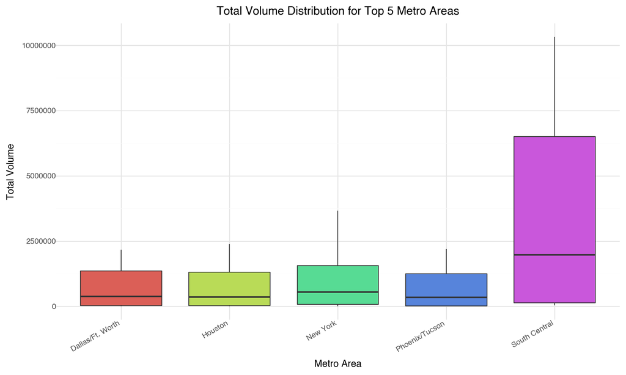

```python
import pandas as pd
from plotnine import ggplot, aes, geom_boxplot, labs, theme_minimal, theme, element_text
non_metro = [
    "TotalUS", "Total U.S.", "West", "SouthCentral", "Southeast",
    "Northeast", "GreatLakes", "Midsouth", "Plains", "WestTexNewMexico", 'California', 'Great Lakes', "Los Angeles"
]

df_metro = df[~df["geography"].isin(non_metro)]

metro_avg = (
    df_metro.groupby("geography")["total_volume"]
    .mean()
    .sort_values(ascending=False)
    .head(5)
)

top5 = metro_avg.index.tolist()

df_top5 = df_metro[df_metro["geography"].isin(top5)]

metrop = (
    ggplot(df_top5, aes(x="geography", y="total_volume", fill="geography"))
    + geom_boxplot()
    + labs(
        title="Total Volume Distribution for Top 5 Metro Areas",
        x="Metro Area",
        y="Total Volume"
    )
    + theme_minimal()
    + theme(
        axis_text_x=element_text(rotation=30, ha="right"),
        legend_position="none",
        figure_size=(10, 6)
    )
)
metrop
```

From the box plot we created we can see the South Central is the largest metro region of the US for avocado volume sales.

Part 6: Create a new data set with only specifc california regions

```python
ca_regions = ["Los Angeles", "San Diego", "Sacramento", "San Francisco"]
df_ca = df[df["geography"].isin(ca_regions)].copy()
```

Part 7

```
type           conventional   organic  difference
geography
San Francisco      1.400490  2.119444    0.718954
San Diego          1.113856  1.798366    0.684510
Sacramento         1.295359  1.873856    0.578497
Los Angeles        1.047124  1.574902    0.527778
```

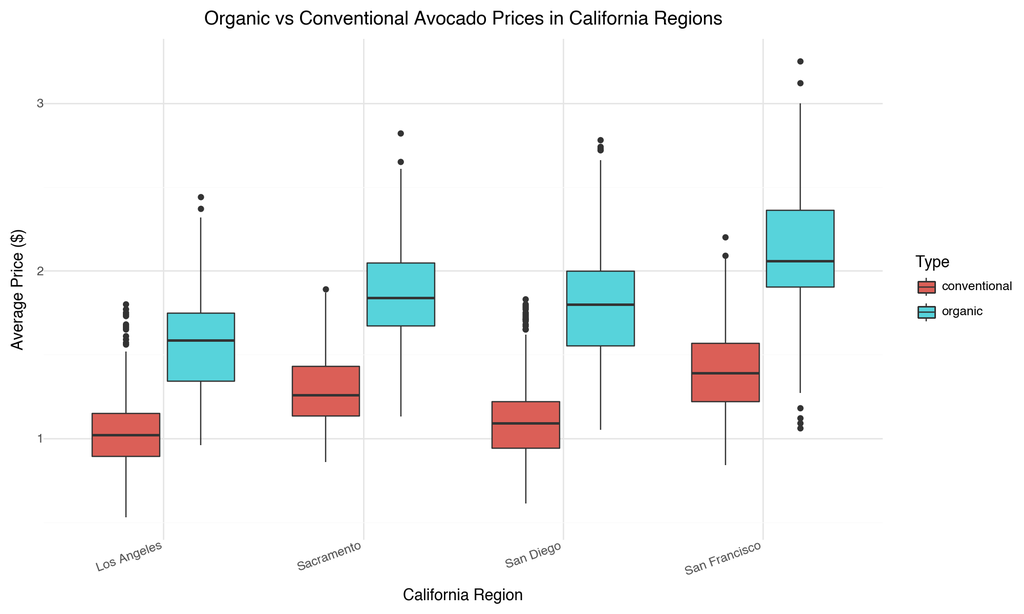

```python
price_summary = (
    df_ca.groupby(["geography", "type"])["average_price"]
    .mean()
    .reset_index()
    .pivot(index="geography", columns="type", values="average_price")
)

price_summary["difference"] = abs(price_summary["organic"] - price_summary["conventional"])
print(price_summary.sort_values("difference", ascending=False))
from plotnine import ggplot, aes, geom_boxplot, labs, theme_minimal, theme, element_text

(
    ggplot(df_ca, aes(x="geography", y="average_price", fill="type"))
    + geom_boxplot()
    + labs(
        title="Organic vs Conventional Avocado Prices in California Regions",
        x="California Region",
        y="Average Price ($)",
        fill="Type"
    )
    + theme_minimal()
    + theme(
        axis_text_x=element_text(rotation=20, ha="right"),
        figure_size=(10, 6)
    )
)
```

As we see from the table and plot we can see the difference in price between organic a conventionl is greatest in San Fransico by a marginl amount.

Part 8

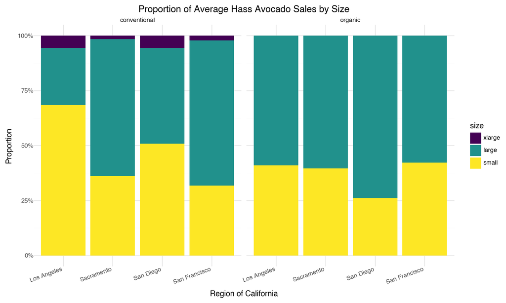

```python
import pandas as pd
from plotnine import (
    ggplot, aes, geom_col, facet_wrap, labs, theme_minimal, theme,
    element_text, scale_y_continuous
)
order = ["Los Angeles", "Sacramento", "San Diego", "San Francisco"]
df_ca["geography"] = pd.Categorical(df_ca["geography"], categories=order, ordered=True)
avg_sizes = (
    df_ca.groupby(["geography", "type"])[["small", "large", "xlarge"]]
    .mean()
    .reset_index()
)
long = (
    avg_sizes.melt(id_vars=["geography", "type"],
                   value_vars=["small", "large", "xlarge"],
                   var_name="size", value_name="avg_volume")
)

group_sums = (
    long.groupby(["geography", "type"])["avg_volume"]
    .sum()
    .reset_index()
    .rename(columns={"avg_volume": "group_total"})
)
long = long.merge(group_sums, on=["geography", "type"])
long["prop"] = long["avg_volume"] / long["group_total"]
long['size']= pd.Categorical(long['size'],categories= ['xlarge','large',"small"], ordered= True)
p = (
    ggplot(long, aes(x="geography", y="prop", fill="size"))
    + geom_col()
    + facet_wrap("~type", nrow=1)
    + scale_y_continuous(labels=lambda v: [f"{x:.0%}" for x in v])
    + labs(
        title="Proportion of Average Hass Avocado Sales by Size",
        x="Region of California",
        y="Proportion",
        fill="size"
    )
    + theme_minimal()
    + theme(
        axis_text_x=element_text(rotation=20, ha="right"),
        figure_size=(10, 6)
    )
)
p
```

Using Outsdie data

```python
import pandas as pd
cities = ["Los Angeles", "San Diego", "Sacramento", "San Francisco"]
housing = pd.read_csv("Data/FHFA House Price Index Master.csv").dropna()
housing["place_name"] = (
    housing["place_name"]
    .astype(str)
    .replace({
        r"^San Francisco.*": "San Francisco",
        r"^Los Angeles.*": "Los Angeles",
        r"^Sacramento.*": "Sacramento",
        r"^San Diego.*": "San Diego"
    }, regex=True)
)
#| eco : true
```

```python
housing = housing[housing["place_name"].isin(cities)].copy()
housing = housing.rename(columns={"place_name": "City"})
df_ca = df_ca.rename(columns={"geography": "City"})
```

```python
merged = pd.merge(df_ca, housing, on="City", how="inner")
merged["average_price_scaled"] = merged["average_price"] * 100
summary = (
    merged.groupby("City", as_index=False)[["average_price_scaled", "total_volume", "index_nsa"]]
    .mean()
)
```

```python
long_price_index = summary.melt(
    id_vars="City",
    value_vars=["average_price_scaled", "index_nsa"],
    var_name="Metric",
    value_name="Value"
)
```

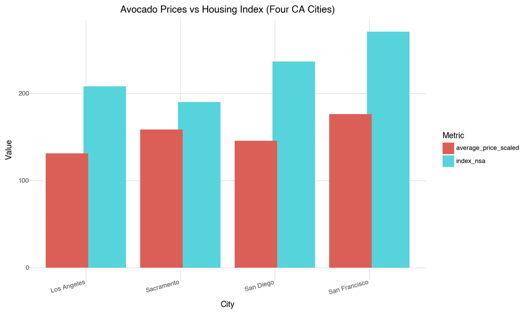

```python
from plotnine import ggplot, aes, geom_bar, labs, theme_minimal, theme, element_text, position_dodge, geom_point, geom_smooth
p_bars = (
    ggplot(long_price_index, aes(x="City", y="Value", fill="Metric"))
    + geom_bar(stat="identity", position=position_dodge(width=0.8))
    + labs(
        title="Avocado Prices vs Housing Index (Four CA Cities)",
        x="City",
        y="Value",
        fill="Metric"
    )
    + theme_minimal()
    + theme(axis_text_x=element_text(rotation=15, ha="right"), figure_size=(10, 6))
)
p_bars
```

As we can see we from the chart we can not see a direct influence of avocado prices on house prices. While San Fran is the most expeensive for both, sacromento has the 2nd most expesnive avocado prices but has the cheapest home prices.